# Pilot_Analysis

# *General analysis plan*

Our analysis will evaluate the pilot outcomes for the Perceived Social Categorization Study. Participants rated the same set of 85 photos for perceived “Jewishness” and “Arabness.” Our objective is to pinpoint images where the average ratings across these two dimensions do not significantly diverge. This nuanced approach enables us to select images that best represent a balanced perception, laying a robust foundation for our main study and ensuring the integrity and relevance of our visual stimuli.

## Data importation and initial preparation

### helper function’s

#### standardize column names

Utilize the provided helper function colnames_to_underscores to standardize column names by replacing spaces and special characters with underscores.

```r
colnames_to_underscores <- function(data = NULL) {
  dat <- data
  names(dat) <- stringr::str_replace_all(names(dat), pattern = " ", replacement = "_")
  return(dat)
  }
```

#### get_summary_stats_function

```r
get_summary_stats <- function(demo_wide_clean) {
  summary_stats <- summary(demo_wide_clean)
  return(summary_stats)
}
```

### Data Importation and Initial Preparation:

Import data sets related to the main task, attention checks, and demographics.

```r
data_categorization_roei <- read_csv("../Data/data-task-ib3a_roei.csv", show_col_types = F)
data_categorization_shani <- read_csv("../Data/data-task-ib3a_shani1.csv", show_col_types = F)
data_categorization_noa <- read_csv("../Data/data-task-4qo7_noa.csv", show_col_types = F)



att_check_roei <- read_csv("../Data/data-task-sfst_roei.csv", show_col_types = F)
att_check_shani <- read_csv("../Data/data-task-sfst_shani1.csv", show_col_types = F)
att_check_noa <- read_csv("../Data/data-task-sfst_noa.csv", show_col_types = F)

data_demo_roei <- read_csv("../Data/data-questionnaire-jj6n_roei.csv", show_col_types = F)
data_demo_shani <- read_csv("../Data/data-questionnaire-jj6n_shani1.csv", show_col_types = F)
data_demo_noa <- read_csv("../Data/data-questionnaire-jj6n_noa.csv", show_col_types = F)
```

## Attention Check and Participant Filtering:

### Data arrangement(Binding- will not be nessasery in the actual analysis)

```r
att_check <- rbind(att_check_roei, att_check_shani, att_check_noa)|>
  colnames_to_underscores() |>
  dplyr::filter(str_detect(Zone_Type, pattern = "endValue")) |>
  select(Participant_Private_ID, Response) |>
  mutate(Participant_Private_ID = factor(Participant_Private_ID))
```

### Identify and exclude participants who failed the attention checks

Identifying who failed the attention checks (answer > 5)

```r
failed_IDs <- att_check |>
  dplyr::filter(Response > 5) |>
  select(Participant_Private_ID)
```

## Data cleaning and Outlier Detection:

### Cleaning data before filtering outliers

- Merge task-related data from different data- sets and filter out participants who failed the attention checks.
- Organizing the primary data for participants, including labeling and introducing a column to denote the order of conditions.

```r
data_participants <- rbind(data_categorization_roei,data_categorization_shani,
                           data_categorization_noa)|>
  colnames_to_underscores() |>
  dplyr::filter(!(Participant_Private_ID %in% failed_IDs$Participant_Private_ID)) |>
  dplyr::filter(display %in% c("task_Jewish", "task_Arab")) |> # removing instructions screens
  dplyr::filter(Zone_Type == "response_slider_endValue") |> # only subjects answers
  select(Participant_Private_ID, Response, image, Reaction_Time, display, Task_Name) |>
  mutate(Participant_Private_ID = factor(Participant_Private_ID),
         image = factor(image),
         Task_Name = factor(Task_Name),
         display = factor(display)) |>
  mutate(Task_Name =  case_when(
    Task_Name == "Group_categorization_JewishFirst_pilot2" ~ "JewishFirst",
    Task_Name == "Group_categorization_ArabFirst_pilot2" ~ "ArabFirst",
    TRUE ~ Task_Name
  )) |>
  rename(order_of_conditions = Task_Name)
```

#### visualizing responses by display

Density plots for participants’ responses based on the dysplay conditions, labeled as “task Arab” versus “task Jewish.”

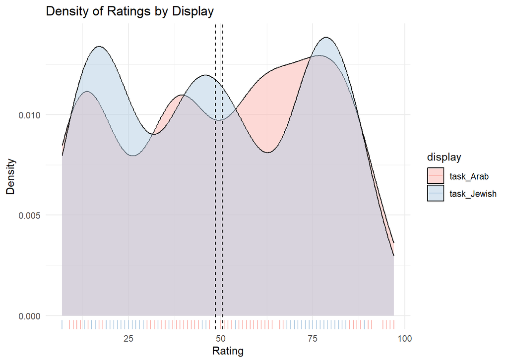

Subjects responses by display

```r
density_plot2 <- ggplot(data_participants, aes(x = Response, fill = display)) +
  geom_density(alpha = 0.5) + # Plot density
  geom_rug(aes(color = display), sides = "b") + # Add rug plot at the bottom
  scale_fill_brewer(palette = "Pastel1") + # Use Pastel1 palette for fill
  scale_color_brewer(palette = "Pastel1") + # Use Pastel1 palette for rug and mean line colors
  theme_minimal() +
  labs(title = "Density of Ratings by Display", x = "Rating", y = "Density") +
  geom_vline(data = data_participants %>% group_by(display) |>
               summarise(mean_response = mean(Response, na.rm = TRUE)),
             aes(xintercept = mean_response),
             linetype = "dashed", color = "black", size = 0.5)
print(density_plot2)
```

### Detecting outlires

Identify and exclude outliers from our data set using The MAD-median rule for outlier removal as recommended by Bakker and Wicherts (2014).

First option to pbtain the MAD MEDIAN ROLE for detecting outlires [link](https://rdrr.io/cran/Routliers/man/outliers_mad.html).

- b is a scaling factor for the MAD to make it consistent for the normal distribution (the default is 1.4826
- threshold is the cutoff value above which values are considered outliers (default is 3)

```r
#code block 1
# Assuming outliers_mad is defined like this:
outliers_mad <- function(x, b = 1.4826, threshold = 3, na.rm = TRUE) {
  if(na.rm) {
    x <- na.omit(x)
  }
  mad_value <- mad(x, constant = b)
  median_value <- median(x)
  deviation <- abs(x - median_value) / mad_value
  return(deviation > threshold)
}
data_participants <- data_participants |>
  mutate(is_outlier = ifelse(outliers_mad(Response, b = 1.4826, threshold = 3, na.rm = TRUE), 1, 0))

# filter out outliers directly
data_cleaned <- data_participants %>% filter(is_outlier == 0)

# If you want to analyze a specific column and store results
response_outliers <- outliers_mad(data_participants$Response, b = 1.4826, threshold = 3, na.rm = TRUE)
```

Second option to pbtain the MAD MEDIAN ROLE for detecting outlires (better in my opinion) [link](https://statsandr.com/blog/outliers-detection-in-r/).

```r
#Threshold Determiantion

threshold <- 2.24
# Calculate the median and MAD for the Response column
median_response <- median(data_participants$Response, na.rm = TRUE)
mad_response <- mad(data_participants$Response, constant = 1, na.rm = TRUE)

lower_bound <- median_response - threshold * mad_response
upper_bound <- median_response + threshold * mad_response

outlier_indices <- which(data_participants$Response < lower_bound | data_participants$Response > upper_bound)


data_participants$is_outlier <- ifelse(data_participants$Response < lower_bound | data_participants$Response > upper_bound, 1, 0)

outliers <- data_participants[outlier_indices, ]
data_cleaned <- data_participants[!data_participants$Response %in% outliers$Response, ]
```

### SD table

A table showing the average standard deviation of each subject’s ratings beyond display types

```r
participant_sd_ratings <- data_participants |>
  group_by(Participant_Private_ID) |>
  summarise(SD_of_Ratings = sd(Response, na.rm = TRUE)) |>
  ungroup()

kable(participant_sd_ratings, caption = "Standard Deviation of Ratings for Each Participant")
```

Standard Deviation of Ratings for Each Participant

| Participant_Private_ID | SD_of_Ratings |
| --- | --- |
| 10070164 | 35.070715 |
| 10072941 | 9.677753 |
| 10129921 | 24.515368 |

### examining order effect:

Examining how the order of conditions affects ratings of images as “Arab” or “Jewish,” to ensure there is no influence of presentation sequence on perceptions. *Visualization of order effect*

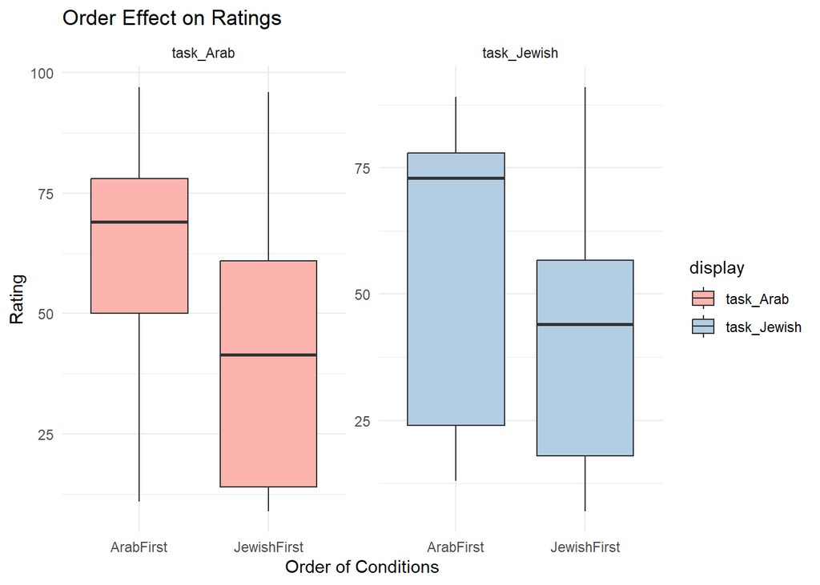

```r
# Visualization of order effects
ggplot(data_participants, aes(x = order_of_conditions, y = Response, fill = display)) +
  geom_boxplot() +
  facet_wrap(~display, scales = "free") +
  labs(title = "Order Effect on Ratings",
       x = "Order of Conditions",
       y = "Rating") +
  theme_minimal() +
  scale_fill_brewer(palette = "Pastel1")
```

Examining order effect first using regression analysis:

```r
order_effect <- lm(Response ~ order_of_conditions, data = data_participants)

print(parameters::model_parameters(order_effect))
```

```
Parameter                         | Coefficient |   SE |          95% CI | t(508) |      p
------------------------------------------------------------------------------------------
(Intercept)                       |       59.33 | 1.95 | [ 55.50, 63.16] |  30.45 | < .001
order of conditions [JewishFirst] |      -14.66 | 2.39 | [-19.34, -9.97] |  -6.14 | < .001
```

Perform a t-test to see if there’s a significant difference in ratings between orders

```r
mean_ratings_by_order <- data_participants |>
  group_by(order_of_conditions, display) |>
  summarise(mean_rating = mean(Response, na.rm = TRUE), .groups = 'drop') |>
  pivot_wider(names_from = display, values_from = mean_rating)


t_test_result_jewish <- t.test(Response ~ order_of_conditions,
                               data = dplyr::filter(data_participants, display == "task_Jewish"),
                               alternative = "two.sided")

t_test_result_arab <- t.test(Response ~ order_of_conditions,
                             data = dplyr::filter(data_participants, display == "task_Arab"),
                             alternative = "two.sided")
```

#### T-test result

```r
t_test_results <- data.frame(
  Display = c("Jewish", "Arab"),
  Statistic = c(t_test_result_jewish$statistic, t_test_result_arab$statistic),
  P_Value = c(t_test_result_jewish$p.value, t_test_result_arab$p.value)  # Difference of means, NA for the second row
)

# Create a table from the results
kable(t_test_results, caption = "T-Test Results for Jewish and Arab Displays", format = "markdown")
```

T-Test Results for Jewish and Arab Displays

| Display | Statistic | P_Value |
| --- | --- | --- |
| Jewish | 3.730102 | 2.66e-04 |
| Arab | 5.186919 | 5.00e-07 |

## Main task

### Difference of means per image by display

- Analyze the main task by calculating and comparing mean responses for different image categories.
- Identify significant differences in means and categorize images based on these differences.

```r
data_images <- data_participants |>
  group_by(image, Participant_Private_ID) |>
  dplyr::summarize(
    task_Jewish = mean(Response[display == "task_Jewish"], na.rm = TRUE),
    task_Arab = mean(Response[display == "task_Arab"], na.rm = TRUE),
    .groups = 'drop'  ) |> # Calculate the difference in ratings for each participant and image
  mutate(diff_per_participant = task_Jewish - task_Arab) |>
  # Aggregate at the image level
  group_by(image) |>
  dplyr::summarize(
    avg_diff = mean(diff_per_participant, na.rm = TRUE),
    .groups = 'drop') |># Classify based on the average difference
  mutate(
    rated_ethnicity = case_when(
      avg_diff < -10 ~ "Arab",
      avg_diff > 10 ~ "Jewish",
      TRUE ~ "Ambiguous"
    )
  )

data_images_big_diff <- data_images |>
  dplyr::filter(abs(avg_diff) >= 10) |>
  mutate(rated_ethnicity = case_when(avg_diff < 0 ~ "Arab",
                                     avg_diff > 0 ~ "Jewish",
                                     .default = NA))
data_images_choosen <- data_images |>
  dplyr::filter(abs(avg_diff)<10)|>
  mutate(rated_ethnicity = case_when(avg_diff < 0 ~ "Arab",
                                     avg_diff > 0 ~ "Jewish",
                                     .default = NA))
```

## Visualization with ggplot2:

### Responses and overall trends per image by display

Visualizing image ratings in both display forms.

```r
plot_images <- data_participants |>
  group_by(display, image) |>
  mutate(per_condition_mean = mean(Response, na.rm = T)) |>
  #filter(str_detect(image, pattern = "20")) |>
  ggplot(aes(x = display, y = Response)) +
  geom_point() +
  geom_point(aes(y = per_condition_mean, color = "red"), show.legend = F) +
  facet_wrap(~image, scales = "fixed") +
  scale_y_continuous(labels = seq(0, 100, 10), breaks = seq(0, 100, 10)) +
  theme(axis.text.x = element_text(angle = 90, vjust = .5, hjust = 1)) +
  theme_classic()

ggsave("plot_images.png", plot = plot_images, path = "../Plots/", width = 4000, height = 4000, units = "px")
```

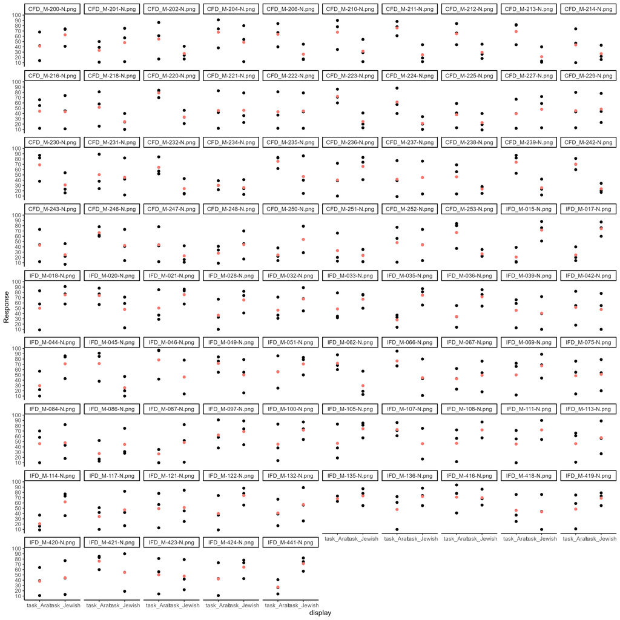

alt text: Overall trends per image by display

```r
# Ensure the data is grouped and then summarize
data_wide <- data_participants |>
  group_by(image, display) |>
  dplyr::summarize(mean_response = mean(Response, na.rm = TRUE), .groups = 'drop')

# Reshaping the data to wide format
data_wide <- data_wide |>
  pivot_wider(names_from = display, values_from = mean_response)

# Calculating the difference
data_diff <- data_wide |>
  mutate(diff = abs(`task_Arab` - `task_Jewish`), # Replace with your actual display column names
         diff_less_than_10 = ifelse(diff < 10, "same", "no_same"))

# Merging the difference back into the original data
data_participants1 <- data_participants |>
  left_join(data_diff, by = "image")

data_participants1 <- data_participants1 |>
  group_by(image, display) |>
  mutate(per_condition_mean = mean(Response, na.rm = TRUE)) |>
  ungroup()

# Creating the plot
plot1 <- data_participants1 |>
  ggplot(aes(x = display, y = Response, color = diff_less_than_10)) +
  geom_point() +
  geom_point(aes(y = per_condition_mean, color = "mean"), show.legend = F) +
  facet_wrap(~image, scales = "fixed") +
  scale_y_continuous(labels = seq(0, 100, 10), breaks = seq(0, 100, 10)) +
  theme(axis.text.x = element_text(angle = 90, vjust = .5, hjust = 1)) +
  theme_classic() +
  scale_color_manual(values = c("same" = "#E84646", "no_same" = "black", "mean" = "#7B8FD4"))


# Display the plot

ggsave("plot1.png", plot = plot1, path = "../Plots/", width = 4000, height = 4000, units = "px")
```

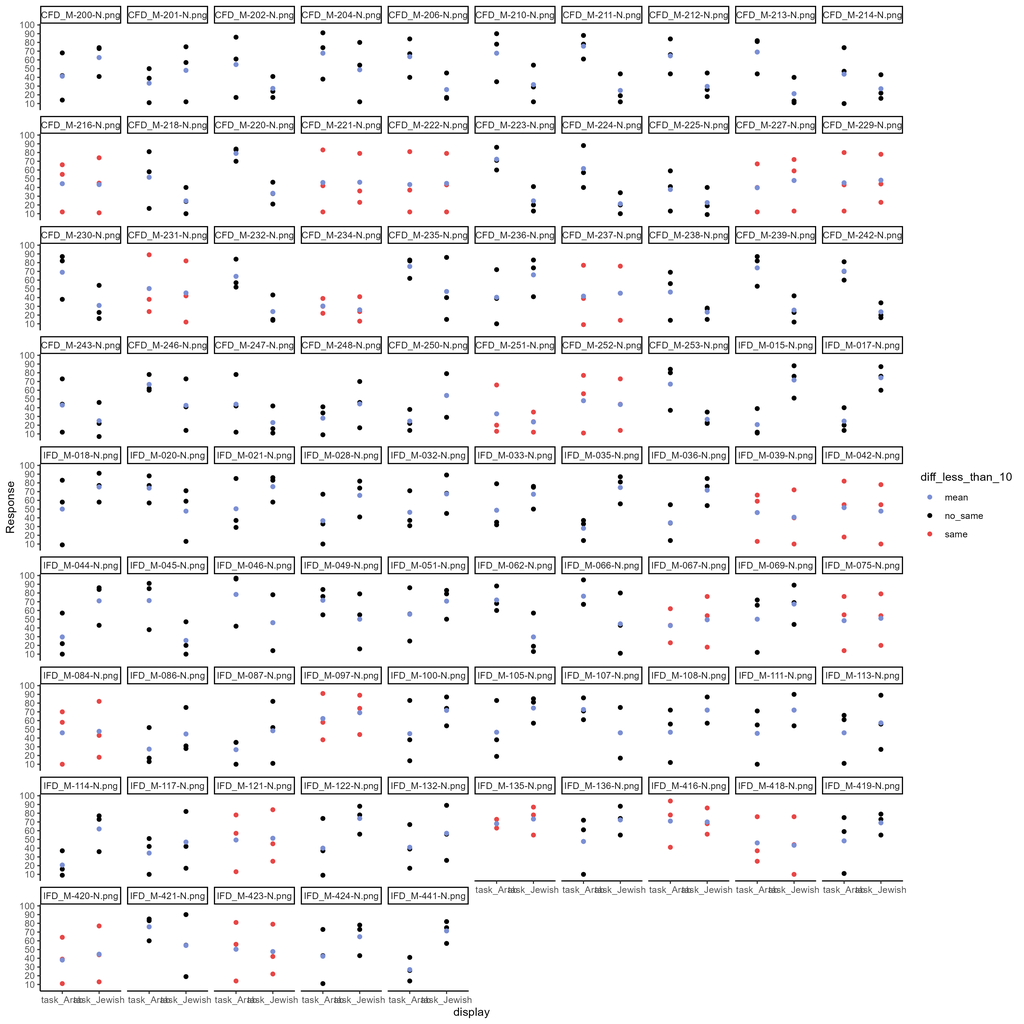

alt text: Overall trends per image by display,

### Participants ratings- individual participant responses and overall trends

```r
plot_participants <- data_participants |>
  group_by(Participant_Private_ID, display) |>
  mutate(participant_mean = mean(Response, na.rm = T)) |>
  ggplot(aes(x = display, y = Response)) +
  geom_point() +
  geom_point(aes(y = participant_mean, color = "red"), show.legend = F) +
 # geom_label_repel(aes(y = participant_mean, label = participant_mean)) +
  facet_wrap(~Participant_Private_ID) +
  scale_x_discrete(labels = c("Arab", "Jewish")) +
  scale_y_continuous(breaks = seq(0, 100, 10), labels = seq(0, 100, 10)) +
  labs(x = "") +
  theme_classic()


ggsave("plot_participants.png", plot = plot_participants, path = "../Plots/", width = 1400, height = 1300, units = "px")
```

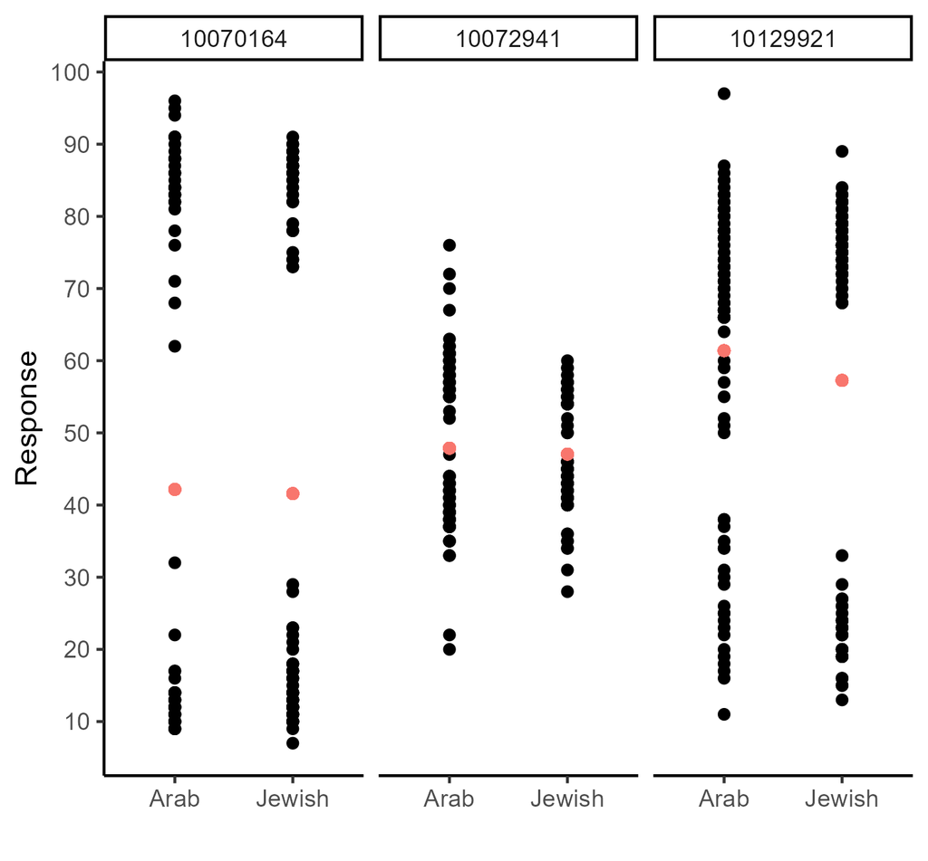

alt text: Participants ratings

Adding lines that connects between the ratings of each image:

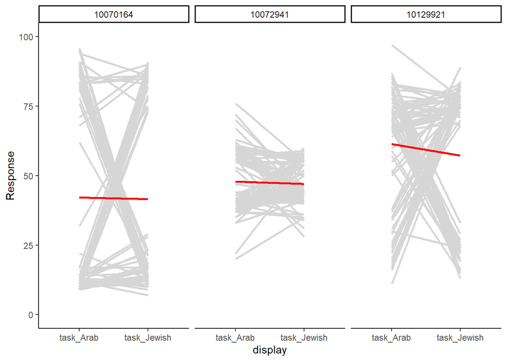

```r
#plot_participants12 <- data_participants |>
  #group_by(Participant_Private_ID, image, display) |>  # Keep 'display' in the grouping
  #mutate(participant_mean = mean(Response, na.rm = TRUE)) |>
  #ggplot(aes(x = display, y = Response, group = interaction(Participant_Private_ID, image), color = interaction(Participant_Private_ID, image))) +  # interaction() combines the participant ID and image ID for grouping
  #geom_point(aes(y = participant_mean), color = "red", show.legend = FALSE) +
  #geom_point() +
  #geom_line(aes(group = interaction(Participant_Private_ID, image)), color = "gray65") +
  #facet_wrap(~Participant_Private_ID) +
  #scale_x_discrete(labels = c("Arab", "Jewish")) +
  #scale_y_continuous(breaks = seq(0, 100, 10), labels = seq(0, 100, 10)) +
  #labs(x = "") +
  #theme_classic()



plot_participants_with_line <- data_participants |>
  ggplot(aes(x = display, y = Response)) +
  geom_smooth(aes(x = display, y = Response, group = image), method = "lm", color = "gray84", se = F, inherit.aes = F) +
  geom_smooth(aes(group = -1), method = "lm", se = F, color = "red") +
  facet_wrap(~Participant_Private_ID) +
  scale_y_continuous(limits = c(0, 100)) +
  theme_classic()




plot_participants_with_line
```

## Demographics

### Data_set arrangment

- Import and clean demographic data.
- Perform necessary transformations and renamings of demographic variables.
- Generate summary statistics and visualizations for demographic variables such as age, gender, religiosity, education, and socio-economic status.

```r
data_demo <- rbind(data_demo_roei, data_demo_shani, data_demo_noa) |>
  colnames_to_underscores() |>
  dplyr::filter(!(Question_Key %in% c("BEGIN QUESTIONNAIRE", "END QUESTIONNAIRE"))) |>
  dplyr::filter(Event_Index != "END OF FILE") |>
  select(Participant_Private_ID, Question_Key, Response) |>
  pivot_wider(names_from = Question_Key, values_from = Response)

data_demo$gender[3] <- "אישה"
```

```r
demo_wide_clean <- data_demo |>
  mutate(gender = case_when(`gender-quantised` == "1" ~ "man",
                            `gender-quantised` == "2" ~ "woman")) |>
  select(-`gender-quantised`, -`gender-quantised`, -`gender-text`, -`ethnic-text`, -`religiosity-quantised`, -`scale_of_SES-quantised`, -`age-quantised`) |>
  mutate(Participant_Private_ID = factor(Participant_Private_ID),
         age = as.numeric(age),
         children = as.numeric(children),
         scale_of_SES = as.numeric(scale_of_SES))

demo_wide_clean$`ethnic-1`[3] <- "ישראלי/ת"
demo_wide_clean$`ethnic-4` <- "יהודי/ת"
demo_wide_clean$education[3] <- " למדתי לימודים מתקדמים מעבר לתואר ראשון"
```

#### Rename columns

```r
demo_wide_clean <- demo_wide_clean |>
  rename(ethnic = `ethnic-1`, SES = scale_of_SES, comment = `response-7`, ethnic2 = `ethnic-4`)
```

### separatlly visualizations and summary statistics for demographic variables

#### Age

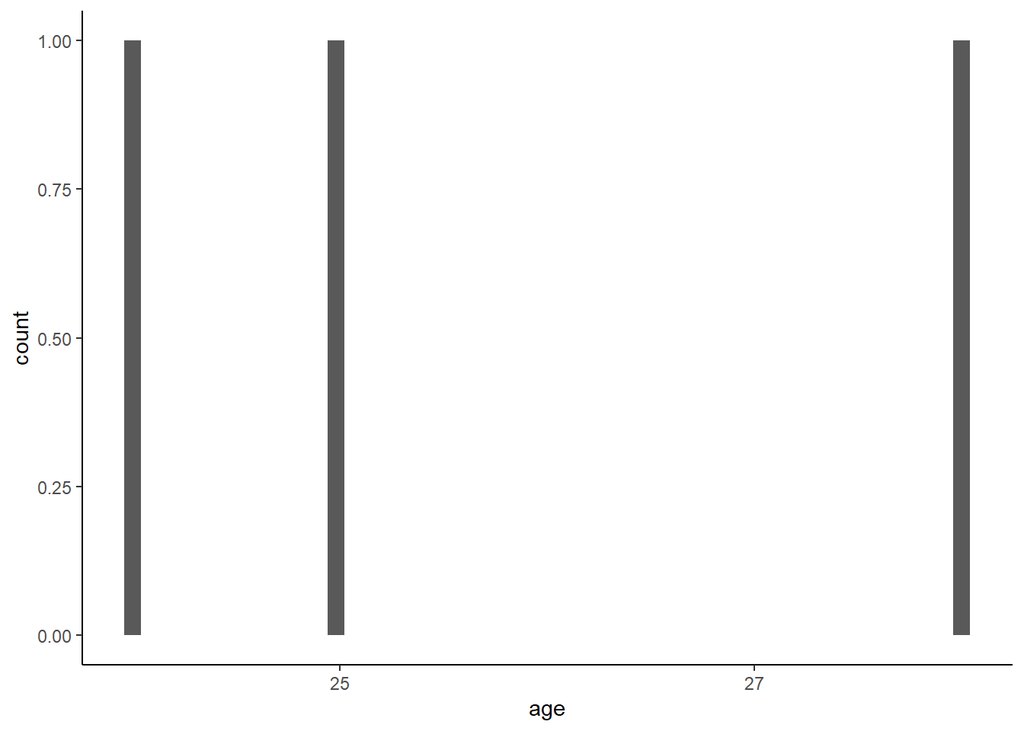

```r
ggplot(demo_wide_clean, aes(x = age)) +
  geom_histogram(bins = 50) +
  scale_x_continuous(breaks = seq(17, 71, 2)) +
  theme_classic()
```

Summary Table for AGE stat:

```r
Age_stats <- get_summary_stats(as.data.frame(as.numeric(demo_wide_clean$age)))

if (!requireNamespace("knitr", quietly = TRUE)) {
  install.packages("knitr")
}

library(knitr)

# Generate a nice table using kable
kable(Age_stats, caption = "Summary Statistics for Age", format = "markdown")
```

Summary Statistics for Age

|  | as.numeric(demo_wide_clean$age) |
| --- | --- |
|  | Min. :24.00 |
|  | 1st Qu.:24.50 |
|  | Median :25.00 |
|  | Mean :25.67 |
|  | 3rd Qu.:26.50 |
|  | Max. :28.00 |

```r
Age_stats_df <- data.frame(
  Statistic = c("Mean", "Median", "SD", "Min", "Max"),
  Value = c(mean(demo_wide_clean$age, na.rm = TRUE),
            median(demo_wide_clean$age, na.rm = TRUE),
            sd(demo_wide_clean$age, na.rm = TRUE),
            min(demo_wide_clean$age, na.rm = TRUE),
            max(demo_wide_clean$age, na.rm = TRUE))
)

kable(Age_stats_df, caption = "Summary Statistics for Age", format = "markdown")
```

Summary Statistics for Age

| Statistic | Value |
| --- | --- |
| Mean | 25.666667 |
| Median | 25.000000 |
| SD | 2.081666 |
| Min | 24.000000 |
| Max | 28.000000 |

#### Gender

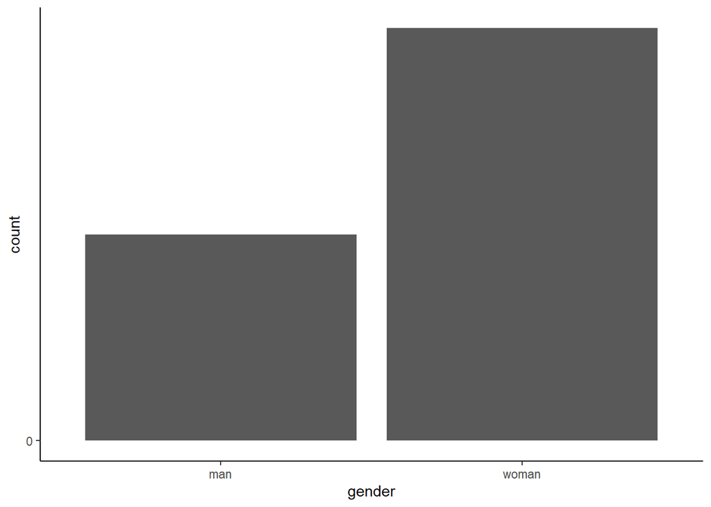

```r
ggplot(demo_wide_clean, aes(x = gender)) +
  geom_histogram(stat = "count") +
  scale_y_continuous(breaks = seq(0, 200, 10)) +
  theme_classic()
```

```r
male_per <- sum(demo_wide_clean$gender == "man")/nrow(demo_wide_clean)
female_per <- sum(demo_wide_clean$gender == "woman")/nrow(demo_wide_clean)
a_baniari_per <- sum(demo_wide_clean$gender == "לא בינארי")/nrow(demo_wide_clean)
```

#### Religiosity

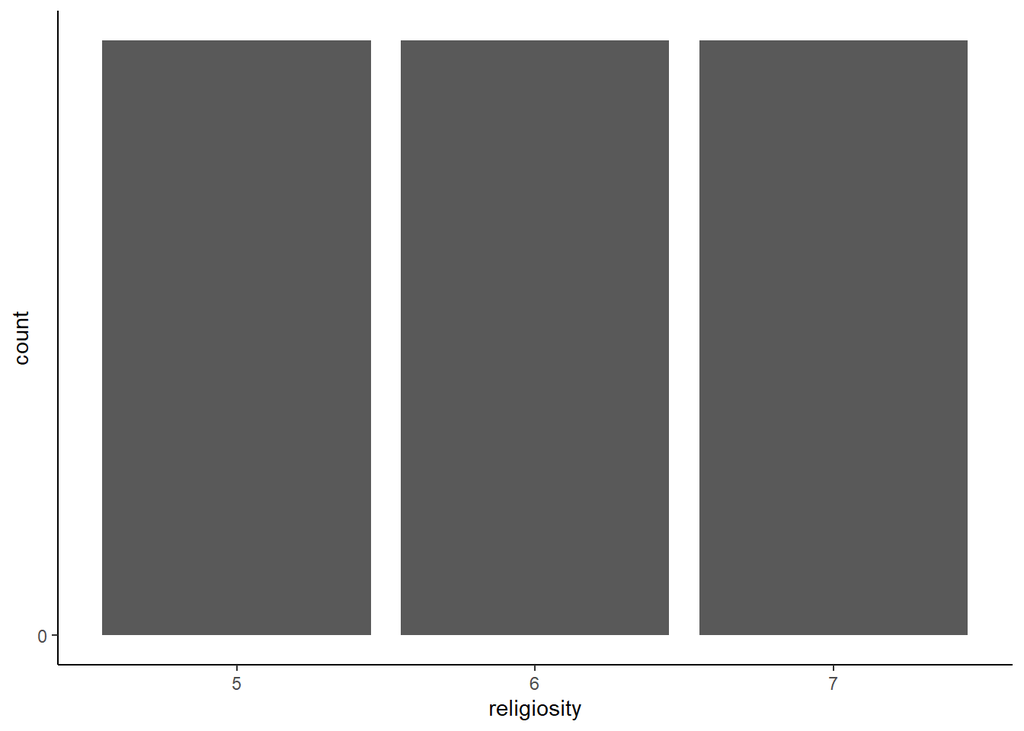

```r
ggplot(demo_wide_clean, aes(x = religiosity)) +
  geom_histogram(stat = "count") +
  scale_y_continuous(breaks = seq(0, 200, 10)) +
  theme_classic()
```

Summary Table for Religiosity stat:

```r
religiosity_stats <- get_summary_stats(as.data.frame(as.numeric(demo_wide_clean$religiosity)))
Age_stats <- get_summary_stats(as.data.frame(as.numeric(demo_wide_clean$age)))

if (!requireNamespace("knitr", quietly = TRUE)) {
  install.packages("knitr")
}

library(knitr)

# Generate a nice table using kable
kable(religiosity_stats, caption = "Summary Statistics for religiosity", format = "markdown")
```

Summary Statistics for religiosity

|  | as.numeric(demo_wide_clean$religiosity) |
| --- | --- |
|  | Min. :5.0 |
|  | 1st Qu.:5.5 |
|  | Median :6.0 |
|  | Mean :6.0 |
|  | 3rd Qu.:6.5 |
|  | Max. :7.0 |

```r
relig_stats_df <- data.frame(
  Statistic = c("Mean", "Median", "SD", "Min", "Max"),
  Value = c(mean(demo_wide_clean$religiosity, na.rm = TRUE),
            median(demo_wide_clean$religiosity, na.rm = TRUE),
            sd(demo_wide_clean$religiosity, na.rm = TRUE),
            min(demo_wide_clean$religiosity, na.rm = TRUE),
            max(demo_wide_clean$religiosity, na.rm = TRUE))
)

kable(relig_stats_df, caption = "Summary Statistics for Religiosity", format = "markdown")
```

Summary Statistics for Religiosity

[output not shown]

```r
demo_table <- flextable::summarizor(demo_wide_clean[,-1], overall_label = "overall") |>
  flextable::as_flextable(sep_w = 0, spread_first_col = T)
```

#### Education

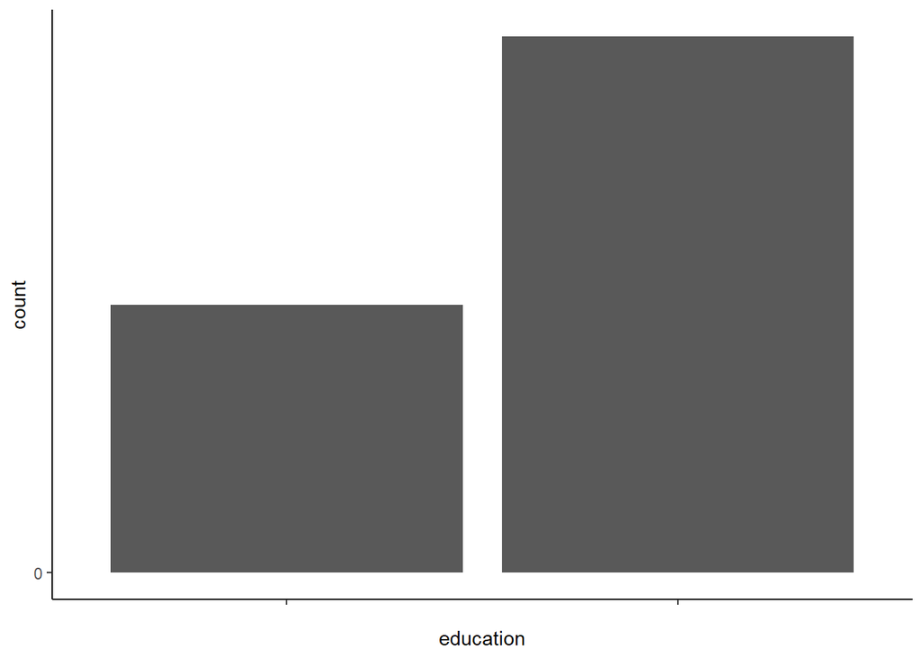

```r
ggplot(demo_wide_clean, aes(x = education)) +
  geom_histogram(stat = "count") +
  scale_y_continuous(breaks = seq(0, 200, 10)) +
  theme_classic()
```

#### SES

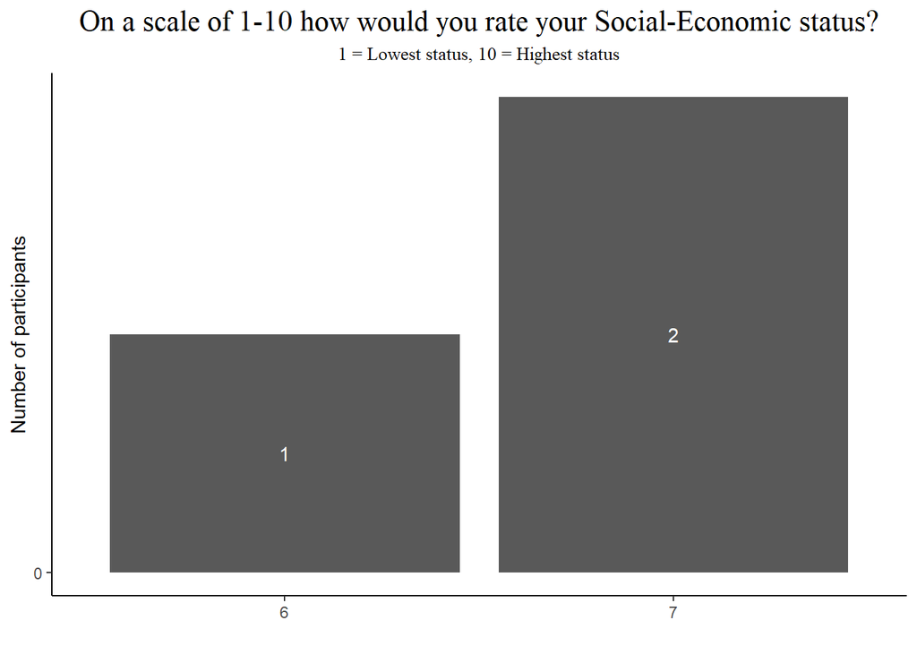

```r
ggplot(drop_na(demo_wide_clean, SES), aes(x = SES)) +
  geom_histogram(stat = "count", binwidth = 1) +
  stat_bin(binwidth = 1, geom = 'text', color = 'white', aes(label = after_stat(count)),
           position = position_stack(vjust = 0.5)) +
  scale_x_continuous(breaks = c(1:10)) +
  scale_y_continuous(breaks = seq(0, 160, 10)) +
  labs(title = "On a scale of 1-10 how would you rate your Social-Economic status?",
       subtitle = "1 = Lowest status, 10 = Highest status",
       y = "Number of participants",
       x = "") +
  theme_classic() +
  theme(plot.title = element_text(family = "serif", hjust = 0.5, size = 16),
        plot.subtitle = element_text(family = "serif", hjust = 0.5, size = 10))
```

Summary Table for SES stat:

```r
SES_stats <- get_summary_stats(as.data.frame(as.numeric(demo_wide_clean$SES)))

# Generate a nice table using kable
kable(SES_stats, caption = "Summary Statistics for SES", format = "markdown")
```

Summary Statistics for SES

|  | as.numeric(demo_wide_clean$SES) |
| --- | --- |
|  | Min. :6.000 |
|  | 1st Qu.:6.500 |
|  | Median :7.000 |
|  | Mean :6.667 |
|  | 3rd Qu.:7.000 |
|  | Max. :7.000 |

```r
SES_stats_df <- data.frame(
  Statistic = c("Mean", "Median", "SD", "Min", "Max"),
  Value = c(mean(demo_wide_clean$SES, na.rm = TRUE),
            median(demo_wide_clean$SES, na.rm = TRUE),
            sd(demo_wide_clean$SES, na.rm = TRUE),
            min(demo_wide_clean$SES, na.rm = TRUE),
            max(demo_wide_clean$SES, na.rm = TRUE))
)

# Now generate the table with kable
kable(SES_stats_df, caption = "Summary Statistics for SES", format = "markdown")
```

Summary Statistics for SES

| Statistic | Value |
| --- | --- |
| Mean | 6.6666667 |
| Median | 7.0000000 |
| SD | 0.5773503 |
| Min | 6.0000000 |
| Max | 7.0000000 |

## References

Bakker, Marjan, and Jelte M Wicherts. 2014. “Outlier Removal, Sum Scores, and the Inflation of the Type i Error Rate in Independent Samples t Tests: The Power of Alternatives and Recommendations.” *Psychological Methods* 19 (3): 409.